# REPAIR from Bayesian and Gaussian latent-variable models

### Mplus Bayes / two-level random-slope model

This is the actual executed Mplus input. `affect` denotes the same observed negative-affect variable called `na` in R. Using `affect` also avoids a parser ambiguity in which the literal variable name `NA` is read as R’s missing value.

```
TITLE: REPAIR Gaussian stress measurement model;
DATA: FILE = stress.dat;
VARIABLE: NAMES = id affect stress_w stress_b;
 USEVARIABLES = affect stress_w stress_b;
 CLUSTER = id; WITHIN = stress_w; BETWEEN = stress_b;
ANALYSIS: TYPE = TWOLEVEL RANDOM;
 ESTIMATOR = BAYES; CHAINS = 4; PROCESSORS = 4; BITERATIONS = (10000); BSEED = 20260918;
MODEL:
 %WITHIN%
 s | affect ON stress_w;
 affect (ve);
 %BETWEEN%
 affect ON stress_b;
 [affect s];
 affect s;
 affect WITH s;
OUTPUT: TECH1 TECH8;
SAVEDATA: FILE = stress_scores.dat; SAVE = FSCORES (1000);
 BPARAMETERS = stress_parameters.dat;
 FORMAT = F20.10;
```

The random slope is defined by `s | affect ON stress_w`; the between-level model gives it a distribution and covariance with the random intercept. Mplus supports these random-effect and factor combinations within its multilevel framework. [Mplus multilevel documentation](https://www.statmodel.com/HTML_UG/chapter9V8.htm).

The report uses the printed Bayesian posterior medians of the fixed effects, residual variance, and random-effect covariance as one plug-in parameter set. Those estimates are rounded to three decimal places by the printed output. Mplus’s default priors also differ from the two Stan fits. These choices are recorded rather than treating the three fits as identical estimators.

`BPARAMETERS` also saves posterior parameter draws, and `FSCORES` saves Bayesian plausible-value summaries. Neither a plausible-value SD nor the covariance of ordinary marginal MCMC score draws is automatically the conditional covariance required by precision subtraction. [Mplus export documentation](https://www.statmodel.com/HTML_UG/chapter18V8.htm).

Fitted plug-in parameters: posterior means for brms/rstanarm; printed posterior medians for Mplus. Generating sigma² = 2.25 and slope variance = .36.

| model | mu0 | mu1 | beta_bw | sigma2 | G00 | G01 | G11 |
| --- | --- | --- | --- | --- | --- | --- | --- |
| brms | 1.0500 | 0.5541 | 0.3714 | 2.2446 | 0.5784 | 0.1394 | 0.3468 |
| rstanarm | 1.0476 | 0.5536 | 0.3705 | 2.2434 | 0.5781 | 0.1396 | 0.3487 |
| mplus | 1.0500 | 0.5530 | 0.3680 | 2.2440 | 0.5840 | 0.1430 | 0.3520 |

### First-stage sampling diagnostics

| Model | Maximum Rhat | Minimum bulk ESS | Divergences | Maximum-depth hits |
| --- | --- | --- | --- | --- |
| brms | 1.007 | 823.797 | 0 | 0 |
| rstanarm | 1.007 | 1163.379 | 0 | 0 |

| Final iteration | Final PSR | Maximum PSR in last 10 checks |
| --- | --- | --- |
| 10000 | 1 | 1 |

Mplus’s normal termination and its full TECH8 potential scale reduction trace are retained in `mplus/stress.out`. These diagnostics concern the first-stage fit; they do not by themselves validate the second-stage plug-in uncertainty calculation.

## Demonstration 2: an Mplus Gaussian factor measurement model

Here the measurement equation is

$$\mathbf y_j=\boldsymbol\nu+\boldsymbol\Lambda\boldsymbol\eta_j+\boldsymbol\varepsilon_j,
\quad\boldsymbol\varepsilon_j\sim N(\mathbf0,\boldsymbol\Theta),
\quad\boldsymbol\eta_j\sim N(\mathbf0,\mathbf G).$$

There are **500 people**, six indicators, and two factors. Each factor has three indicators; its first loading is fixed to one to establish scale. The latent variances are .64 and 1, with covariance .28. Residual covariance between indicators 3 and 4 is .25, creating correlated estimation errors between recovered factor values. Every fourth person is missing indicator 2 by design, independently of all generated variables. The structural coefficients are .25 for factor 1 and .60 for factor 2.

```
TITLE: REPAIR two-factor Gaussian measurement model;
DATA: FILE = factors.dat;
VARIABLE: NAMES = id y1-y6; USEVARIABLES = y1-y6; IDVARIABLE = id; MISSING = ALL(-999);
ANALYSIS: ESTIMATOR = ML;
MODEL:
 f1 BY y1@1 y2 y3;
 f2 BY y4@1 y5 y6;
 f1 WITH f2;
 y3 WITH y4;
OUTPUT: TECH1 TECH4;
SAVEDATA: FILE = factor_scores.dat; SAVE = FSCORES; FORMAT = F20.10;
```

We extract loadings, indicator intercepts, residual variances and covariance, and the latent covariance matrix from Mplus. Each person’s observed-indicator subset defines $\boldsymbol\Lambda_j$, $\boldsymbol\Theta_j$, and $\boldsymbol\nu_j$. The likelihood-only scores are

$$\widehat{\boldsymbol\eta}_j=
(\boldsymbol\Lambda_j^\top\boldsymbol\Theta_j^{-1}\boldsymbol\Lambda_j)^{-1}
\boldsymbol\Lambda_j^\top\boldsymbol\Theta_j^{-1}(\mathbf y_j-\boldsymbol\nu_j),
\quad
\widehat{\boldsymbol\Psi}_j=
(\boldsymbol\Lambda_j^\top\boldsymbol\Theta_j^{-1}\boldsymbol\Lambda_j)^{-1}.$$

These are Bartlett-type scores. Person-specific missingness changes the error covariance, and the correlated residuals produce a nonzero off-diagonal entry. We retain it when calling Fuller.

Two measurement-error covariance patterns, corresponding to complete and partially observed indicator sets.

| v00 | v01 | v11 |
| --- | --- | --- |
| 0.3247 | 0.0447 | 0.2987 |
| 0.3809 | 0.0525 | 0.2998 |

### A pathway using actual saved factor scores

For this ML Gaussian factor model, we also read Mplus’s saved `F1` and `F2` scores, align them by `ID`, reconstruct the conditional covariance from the fitted measurement model, and subtract prior precision. The saved scores are not replaced with our calculated posterior means in this check.

The printed Mplus parameter table has lower precision than the exported scores. Therefore this comparison has small rounding discrepancies; the model-consistent calculations elsewhere agree to machine precision. The largest recovered-score discrepancy is **0.000671**, and the largest Fuller coefficient discrepancy is **0.000005**.

Actual exported Mplus scores versus reconstruction using rounded printed parameters.

| max_export_vs_reconstructed_posterior_mean | max_likelihood_score_difference | max_Fuller_coefficient_difference | max_Fuller_SE_difference |
| --- | --- | --- | --- |
| 0.00043937 | 0.00067121 | 5e-06 | 9.91e-06 |

## Both pathways call the existing Fuller code

Every participant contributes `x0`, `x1`, `v00`, `v01`, and `v11`, plus the observed distal outcome. The adapter sources `R/core_utils.R` and `R/stage2_estimators.R` from the parent repository. It does not duplicate or alter the Fuller estimating equations.

```r
d$zero <- 0
fit_fuller_dual_variants(
  d,
  outcome = "depression",
  predictor_u0 = "x0", predictor_u1 = "x1",
  meas11 = "v00", meas12 = "v01", meas22 = "v11",
  outcome_meas_var = "zero",
  predictor_outcome_meas_cov_u0 = "zero",
  predictor_outcome_meas_cov_u1 = "zero",
  variants = c("stabilized", "fuller_equations"),
  skip_internal_scaling = TRUE
)
```

The zeros specify an observed outcome without separately modeled measurement error and no predictor–outcome measurement-error covariance. They do **not** set the structural residual variance to zero. Raw predictor units are retained so that estimates target the generating coefficient .60. We show the repository’s stabilized variant and its `fuller_equations` variant explicitly.

Direct likelihood versus conditional Gaussian prior removal: maximum absolute discrepancies over people, covariance entries, and both Fuller variants.

| model | max_score_difference | max_ME_difference | max_Fuller_coefficient_difference | max_Fuller_SE_difference |
| --- | --- | --- | --- | --- |
| brms | 1.78e-15 | 2.78e-16 | 8.88e-16 | 2.22e-16 |
| rstanarm | 1.55e-15 | 2.22e-16 | 2.22e-15 | 3.05e-16 |
| mplus | 1.78e-15 | 2.78e-16 | 1.89e-15 | 2.50e-16 |
| Mplus factors | 2.22e-15 | 1.67e-16 | 4.44e-16 | 2.78e-17 |

These checks establish correct transfer of the likelihood and error covariance into the existing code. An additional zero-error test verifies that Fuller coefficients reduce to OLS coefficients when all supplied predictor ME covariances are zero.

### Structural estimates in the realized datasets

Focal structural coefficient; generating value .60. The oracle uses the realized true predictors and is not forced to equal .60.

| model | method | estimate | se | ci_low | ci_high | status_code |
| --- | --- | --- | --- | --- | --- | --- |
| brms | Oracle: true predictors | 0.629 | 0.086 | 0.461 | 0.798 | 0 |
| brms | Likelihood-only / naive OLS | 0.391 | 0.070 | 0.253 | 0.529 | 0 |
| brms | Conditional posterior mean / naive OLS | 0.567 | 0.114 | 0.344 | 0.790 | 0 |
| brms | REPAIR / stabilized | 0.627 | 0.128 | 0.376 | 0.879 | 0 |
| brms | REPAIR / fuller_equations | 0.627 | 0.130 | 0.373 | 0.881 | 0 |
| rstanarm | Oracle: true predictors | 0.629 | 0.086 | 0.461 | 0.798 | 0 |
| rstanarm | Likelihood-only / naive OLS | 0.391 | 0.070 | 0.253 | 0.529 | 0 |
| rstanarm | Conditional posterior mean / naive OLS | 0.566 | 0.114 | 0.343 | 0.788 | 0 |
| rstanarm | REPAIR / stabilized | 0.627 | 0.128 | 0.376 | 0.878 | 0 |
| rstanarm | REPAIR / fuller_equations | 0.627 | 0.130 | 0.373 | 0.881 | 0 |
| mplus | Oracle: true predictors | 0.629 | 0.086 | 0.461 | 0.798 | 0 |
| mplus | Likelihood-only / naive OLS | 0.391 | 0.070 | 0.253 | 0.529 | 0 |
| mplus | Conditional posterior mean / naive OLS | 0.564 | 0.113 | 0.342 | 0.786 | 0 |
| mplus | REPAIR / stabilized | 0.627 | 0.128 | 0.376 | 0.879 | 0 |
| mplus | REPAIR / fuller_equations | 0.627 | 0.130 | 0.373 | 0.881 | 0 |
| Mplus factors | Oracle: true predictors | 0.632 | 0.037 | 0.561 | 0.704 | 0 |
| Mplus factors | Likelihood-only / naive OLS | 0.469 | 0.035 | 0.402 | 0.537 | 0 |
| Mplus factors | Conditional posterior mean / naive OLS | 0.600 | 0.046 | 0.510 | 0.691 | 0 |
| Mplus factors | REPAIR / stabilized | 0.599 | 0.048 | 0.505 | 0.693 | 0 |
| Mplus factors | REPAIR / fuller_equations | 0.599 | 0.048 | 0.505 | 0.693 | 0 |

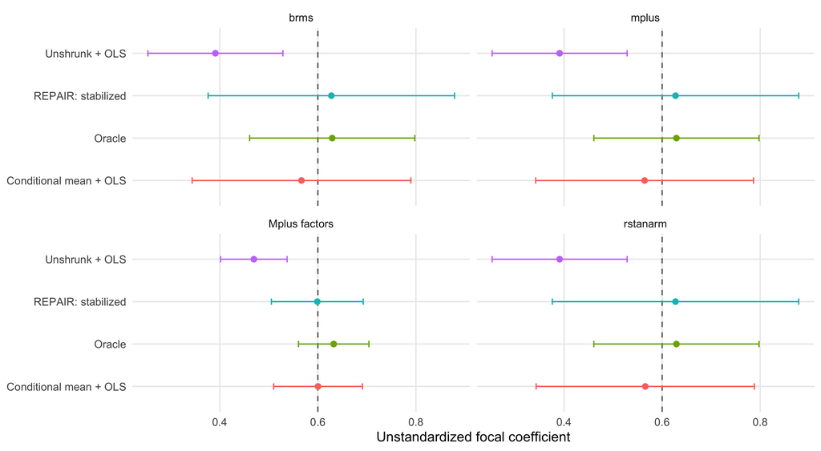

Figure 1: Structural estimates and 95% intervals in the demonstration datasets. Differences across first-stage packages reflect fitted parameters and priors, not different Fuller implementations.

A single dataset cannot establish unbiasedness. The oracle coefficient also varies around .60. Naive regression on shrunken conditional posterior means can perform well in a correctly calibrated linear setting; REPAIR is not guaranteed to dominate it in every simulation. The repeated-cohort results below include that comparison rather than assuming every shrunken predictor must attenuate its structural coefficient.

## Repeated-cohort validation

We generate **250 new datasets of 300 people for each design**, preserving the structural coefficients and measurement setup. All replicates are retained and failures are counted.

This is a **conditional validation experiment**, not a simulation that refits brms, rstanarm, and Mplus in every replication. In the stress experiment, the shared fixed effects and prior covariance are set to their generating values; the common residual variance is re-estimated from pooled within-person OLS residual sums of squares, divided by the total residual degrees of freedom. In the factor experiment, loadings, indicator intercepts, latent prior, and residual covariance are fixed at their generating values. The full fitted-model demonstrations above separately establish the software-export pathways.

This division isolates two questions: whether software outputs can be converted correctly, and whether the resulting additive-error inputs support Fuller correction. It does not establish unconditional coverage after estimating every first-stage parameter.

Repeated-cohort performance. MCSE measures Monte Carlo uncertainty, not the standard error of an individual structural coefficient.

| design | method | attempts | successes | mean_estimate | bias | bias_MCSE | RMSE | coverage | coverage_MCSE |
| --- | --- | --- | --- | --- | --- | --- | --- | --- | --- |
| Factors: fixed measurement parameters | Conditional posterior mean / naive OLS | 250 | 250 | 0.600 | 0.000 | 0.004 | 0.062 | 0.944 | 0.015 |
| Factors: fixed measurement parameters | Likelihood-only / naive OLS | 250 | 250 | 0.471 | -0.129 | 0.003 | 0.137 | 0.180 | 0.024 |
| Factors: fixed measurement parameters | Oracle: true predictors | 250 | 250 | 0.597 | -0.003 | 0.003 | 0.047 | 0.964 | 0.012 |
| Factors: fixed measurement parameters | REPAIR / fuller_equations | 250 | 250 | 0.601 | 0.001 | 0.004 | 0.065 | 0.956 | 0.013 |
| Factors: fixed measurement parameters | REPAIR / stabilized | 250 | 250 | 0.601 | 0.001 | 0.004 | 0.065 | 0.952 | 0.014 |
| Stress: pooled residual variance | Conditional posterior mean / naive OLS | 250 | 250 | 0.591 | -0.009 | 0.007 | 0.109 | 0.936 | 0.015 |
| Stress: pooled residual variance | Likelihood-only / naive OLS | 250 | 250 | 0.378 | -0.222 | 0.004 | 0.231 | 0.084 | 0.018 |
| Stress: pooled residual variance | Oracle: true predictors | 250 | 250 | 0.596 | -0.004 | 0.005 | 0.076 | 0.976 | 0.010 |
| Stress: pooled residual variance | REPAIR / fuller_equations | 250 | 250 | 0.590 | -0.010 | 0.007 | 0.112 | 0.960 | 0.012 |
| Stress: pooled residual variance | REPAIR / stabilized | 250 | 250 | 0.590 | -0.010 | 0.007 | 0.112 | 0.960 | 0.012 |

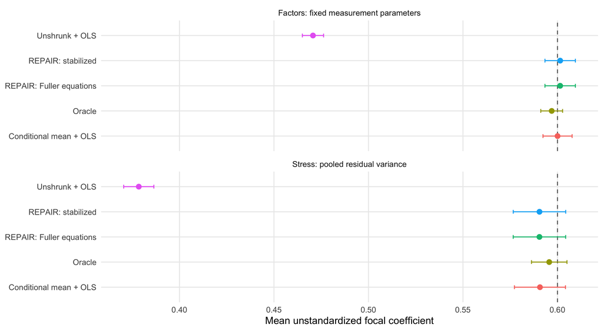

Figure 2: Mean structural estimates across independent simulated cohorts. Intervals are ±1.96 Monte Carlo SE, not individual-model confidence intervals.

The relevant comparison is whether REPAIR reduces the systematic distortion from treating likelihood-only scores as error-free, while its intervals behave reasonably under this conditional design. Both bias and coverage remain Monte Carlo estimates; the report does not label every realized coefficient close to .60 as a successful correction.

**Observed recovery:** for stress reactivity, the mean naive likelihood-score coefficient is **0.378**, compared with **0.590** after REPAIR. The latter’s bias is **-0.010**, with Monte Carlo SE **0.007**, and coverage is **96.0%**. For the factor model, the corresponding naive and REPAIR means are **0.471** and **0.601**, with REPAIR coverage **95.2%**.

Conditional posterior means also preserve the structural relationship well in this example. Their mean coefficients are **0.591** and **0.600**. This is compatible with predictor calibration: when $\mathbf m=E(\boldsymbol\theta\mid\mathbf y)$ under a correct measurement model and the structural residual has mean zero given those measurements, $E(Depression\mid\mathbf y)=\gamma_0+\boldsymbol\gamma^\top\mathbf m$. Thus, the same unstandardized coefficients can survive shrinkage. These results support the REPAIR interface and correction; they do not establish superiority over calibrated conditional means in this favorable linear setting.

## A check with nondiagonal residual covariance

The stress model uses $\sigma^2\mathbf I$, while the factor model already includes a nonzero residual covariance. We additionally check a nine-observation GLS model with AR(1)-shaped residual covariance. Direct matrix identities verify $\mathbf K\mathbf H=\mathbf I$ and $\mathbf K\mathbf R\mathbf K^\top=\boldsymbol\Psi$. Twenty thousand simulated error vectors then check the resulting sampling covariance empirically.

| quantity | analytical | empirical |
| --- | --- | --- |
| variance 1 | 0.4214 | 0.4246 |
| covariance 12 | 0.0000 | -0.0005 |
| variance 2 | 0.7311 | 0.7322 |

This is why nondiagonal $\mathbf R$ requires GLS rather than separate OLS plus an arbitrary variance adjustment.

## Why ordinary posterior draws are not the conditional covariance

brms’s [`ranef(..., summary = FALSE)`](https://paulbuerkner.com/brms/reference/ranef.brmsfit.html) provides posterior random-effect draws. Those draws integrate over uncertainty in shared means, variances, and other parameters. Their covariance is generally not the fixed-hyperparameter conditional $\mathbf C_j$ required above.

To make the distinction concrete, we deliberately take each person’s covariance of marginal brms random-effect draws and subtract the plug-in prior precision. We label this an incorrect adapter, not another valid REPAIR method.

| People | Nonpositive information matrices | Maximum slope discrepancy | Maximum slope ME variance discrepancy |
| --- | --- | --- | --- |
| 300 | 0 | 0.1337 | 0.0894 |

Any difference here combines marginalization, Monte Carlo error, and use of plug-in prior summaries. It is not a pure numerical estimate of marginalization bias. Even if its resulting matrix is positive definite and the discrepancy happens to be small, the exact Gaussian identity does not justify that substitution.

A valid alternative is to calculate conditional moments at each coherent draw of shared parameters. However, running Fuller at each draw and combining the results is not automatically a fully Bayesian posterior or a justified multiple-imputation procedure. A full refitting bootstrap or a jointly specified Bayesian structural model requires its own uncertainty argument.

## What an applied user should save

| Purpose | Required output |
| --- | --- |
| Direct likelihood reconstruction | Original measurement data, IDs, exact design/loadings, offsets/intercepts, and all residual covariance parameters |
| Conditional posterior inversion | Full conditional mean vector, full conditional covariance, matching prior mean and covariance, and the fixed shared parameters defining them |
| Fuller input | Likelihood-only score vector and its full sampling-error covariance for every person |
| Structural model | Distal outcome, observed covariates, units/centering definitions, and matching IDs |
| Uncertainty and reproducibility | Fitted-model object or parameter draws, model syntax, priors, missingness rules, diagnostics, seeds, software versions, and sufficient data to refit |

Several boundaries are consequential:

1. **Recover the jointly coupled vector.** Marginal standard errors alone generally cannot undo multivariate shrinkage. Select the desired slope or factor after recovering the relevant joint vector.
2. **Check identification without the prior.** A proper posterior can exist when the likelihood information is singular. This implementation stops rather than silently replacing an unidentified inverse with a generalized inverse.
3. **Maintain parameter scale and meaning.** Do not mix standardized scores, total coefficients, random deviations, or differently centered intercepts. General nonlinear transformations do not preserve the exact additive-error model.
4. **Allow appropriate residual structure.** Heteroskedasticity, serial correlation, correlated indicators, and missingness alter $\mathbf R_j$ and hence $\boldsymbol\Psi_j$. Pooling an incorrect residual model can miscalibrate the correction.
5. **Keep cross-covariances when both sides are estimated.** Estimated predictor and outcome processes may have correlated errors. The existing Fuller interface has explicit inputs for these covariances; this report’s independently generated observed outcomes use zero.
6. **Separate person independence from Gaussianity.** Crossed effects and shared latent processes may require a stacked calculation and an extension of second-stage inference to correlated errors across people. Four per-person posterior summaries may be insufficient.
7. **Distinguish fitted-model identities from unconditional inference.** Shared parameters are estimated in the demonstrations. Exact algebra at their fitted values does not remove their estimation uncertainty. The repeated-cohort experiment conditions on most of these parameters.

A joint MSEM that already regresses the distal outcome on the latent slope estimates that relationship directly; REPAIR is not an additional correction to its fitted structural coefficient. REPAIR supplies a two-stage alternative when measurement estimation and structural analysis are separated.

## Reproduce and inspect

Run from the repository root:

```bash
Rscript gaussian_repair_pathways/run_models.R all
Rscript gaussian_repair_pathways/analyse.R 250
Rscript gaussian_repair_pathways/tests/check_outputs.R
quarto render gaussian_repair_pathways/report.qmd
```

The fitting script can also run `data`, `brms`, `rstanarm`, and `mplus` separately, in that order for data preparation and then independently for the software fits. Rendering reads completed results and does not silently refit models. Mplus requires a working installation and license; a failed or unavailable Mplus fit stops rather than being replaced with another estimator.

Files in this folder include the reusable Gaussian adapter, simulation generator, actual executed Mplus inputs and outputs, fitted plug-in quantities, person-level scores, all replication-level structural results, package session information, and source hashes for the existing Fuller code. Large cached Bayesian fit objects are kept under `cache/` and ignored by Git.

Source fingerprints recorded when the analyses were executed.

| file | md5 |
| --- | --- |
| gaussian_repair_pathways/R/helpers.R | ea2b36527a10221803918e3e8a116f8e |
| gaussian_repair_pathways/run_models.R | e2c52e26c1e6c562c57ff7245c5f96e3 |
| gaussian_repair_pathways/analyse.R | 077d99658493511515c991f0ced79205 |
| R/core_utils.R | d47a5bfd1e4f646d7d84c60597756be9 |
| R/stage2_estimators.R | cb0b17b1e21236ef7b8550989562e75c |